# Disproportionate exposure to urban heat island intensity in the USA

December 6, 2022

## Introduction

- Urban areas are usually warmer than the rural areas that surround them — Urban heat island
- It could occurs because cities consume huge amounts of energy in electricity and fuel, have less vegetation to provide shade and cooling, and are built of materials that absorb and store heat
- Heat exposure is associated with heat-related mortality, illness, and non-fatal health outcomes.
- Urban heat islands (UHI) might disproportionately impact vulnerable communities (e.g., lower income communities, older people, and black communities)
- Well-targeted interventions are needed to adapt and mitigate to the UHI effect

## Research questions

1. Is UHI intensity disproportionately affecting vulnerable communities? What type of communities are affected more by the UHI intensity?
2. How vegetation index and digital elevation model affect UHI intensity?

## Data description

- **Urban Heat Island data**
  - UHI = urban heat island (55,871 obs.)
  - also use NDVI (vegetation index), LST (land surface temperature); DEM (digital elevation model)
  - source: [Chakraborty, 2020](https://data.mendeley.com/datasets/x9mv4krnm2/3) (data.mendeley.com)
- **Demographic data**
  - age, sex, race at the census tract-level demographic data (74,001 obs)
  - source: [American Community Survey, 2017](https://data.census.gov/table?q=age+&g=0100000US$1400000&y=2017&tid=ACSST5Y2017.S0101) (data.census.gov)
- **Socioeconomic data**
  - poverty rate (74,001 obs); source: [American Community Survey, 2017](https://data.census.gov/table?q=age+&g=0100000US$1400000&y=2017&tid=ACSST5Y2017.S0101) (data.census.gov)

**Representative population:**

- Unit of analysis: tracts by census id (42,183 obs.)
- Population: all tract across US observed in 2017

## Descriptive Findings

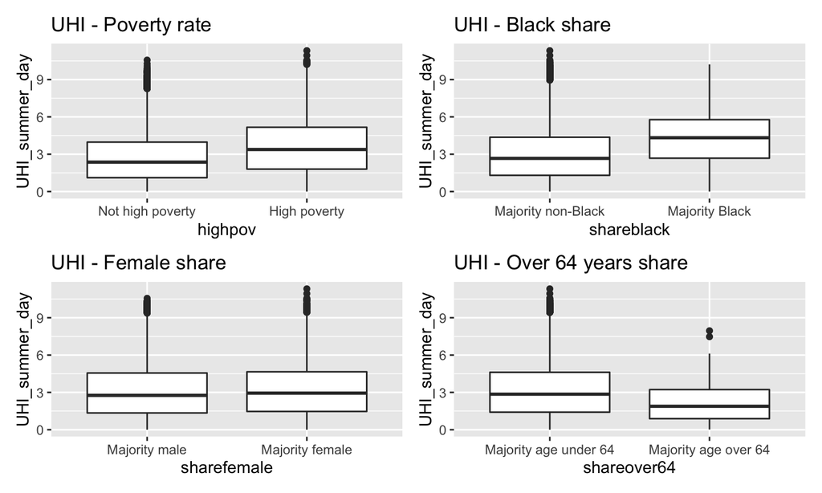

## Descriptive Findings

20 cities with highest UHI intensity

| Urban_name | total | UHI_mean | NDVI_mean | DEM_mean | povt_rate | shareblack | sharefemale | shareover64 |
| --- | --- | --- | --- | --- | --- | --- | --- | --- |
| New Orleans, LA | 829397 | 6.25 | 0.35 | 4.91 | 22.46 | 0.43 | 0.52 | 0.14 |
| New York–Newark, NY–NJ–CT | 16523795 | 5.23 | 0.40 | 29.46 | 14.88 | 0.21 | 0.52 | 0.14 |
| Manchester, NH | 116143 | 4.98 | 0.55 | 88.61 | 15.98 | 0.05 | 0.49 | 0.14 |
| Buffalo, NY | 847328 | 4.88 | 0.52 | 193.05 | 19.51 | 0.19 | 0.52 | 0.16 |
| Providence, RI–MA | 1031247 | 4.81 | 0.54 | 38.92 | 15.58 | 0.07 | 0.51 | 0.15 |
| Antioch, CA | 235279 | 4.78 | 0.27 | 30.12 | 13.49 | 0.15 | 0.51 | 0.12 |
| Bridgeport–Stamford, CT–NY | 740795 | 4.72 | 0.62 | 37.73 | 11.04 | 0.14 | 0.52 | 0.15 |
| Boston, MA–NH–RI | 3736637 | 4.62 | 0.55 | 34.83 | 12.48 | 0.11 | 0.52 | 0.14 |
| Urban Honolulu, HI | 689569 | 4.62 | 0.35 | 64.72 | 10.62 | 0.03 | 0.49 | 0.16 |
| York, PA | 182187 | 4.50 | 0.49 | 146.10 | 18.90 | 0.14 | 0.52 | 0.15 |
| Beaumont, TX | 112711 | 4.45 | 0.45 | 14.06 | 19.52 | 0.45 | 0.51 | 0.15 |
| San Juan, PR | 1637929 | 4.43 | 0.43 | 63.59 | 40.48 | 0.12 | 0.53 | 0.19 |
| San Francisco–Oakland, CA | 2266986 | 4.37 | 0.31 | 34.50 | 11.67 | 0.10 | 0.51 | 0.14 |
| Reading, PA | 244899 | 4.32 | 0.52 | 107.20 | 21.32 | 0.08 | 0.51 | 0.14 |
| Detroit, MI | 3218926 | 4.20 | 0.50 | 203.92 | 21.17 | 0.36 | 0.52 | 0.15 |
| Hartford, CT | 718598 | 4.19 | 0.61 | 54.04 | 15.12 | 0.18 | 0.52 | 0.15 |
| Syracuse, NY | 329974 | 4.14 | 0.55 | 144.20 | 23.11 | 0.18 | 0.52 | 0.14 |
| Houston, TX | 4973841 | 4.13 | 0.39 | 27.13 | 17.57 | 0.20 | 0.50 | 0.10 |
| Scranton, PA | 298887 | 4.09 | 0.52 | 227.06 | 19.00 | 0.05 | 0.51 | 0.19 |
| Philadelphia, PA–NJ–DE–MD | 4755246 | 4.07 | 0.50 | 48.08 | 15.48 | 0.26 | 0.52 | 0.15 |

## Descriptive Findings

### UHI ~ Poverty Rate

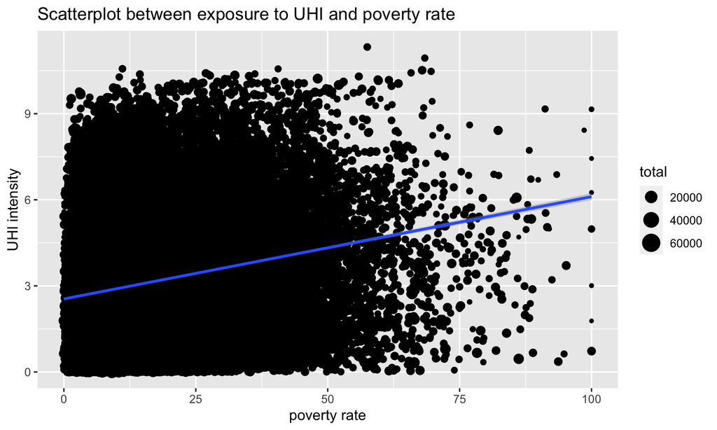

```
##
## t test of coefficients:
##
##               Estimate Std. Error t value  Pr(>|t|)
## (Intercept) 2.37249716 0.01710352  138.71 < 2.2e-16 ***
## povt_rate   0.03689134 0.00088874   41.51 < 2.2e-16 ***
## ---
## Signif. codes:  0 '***' 0.001 '**' 0.01 '*' 0.05 '.' 0.1 ' ' 1
```

## Descriptive Findings

Majority black with higher poverty experienced **higher UHI exposure**.

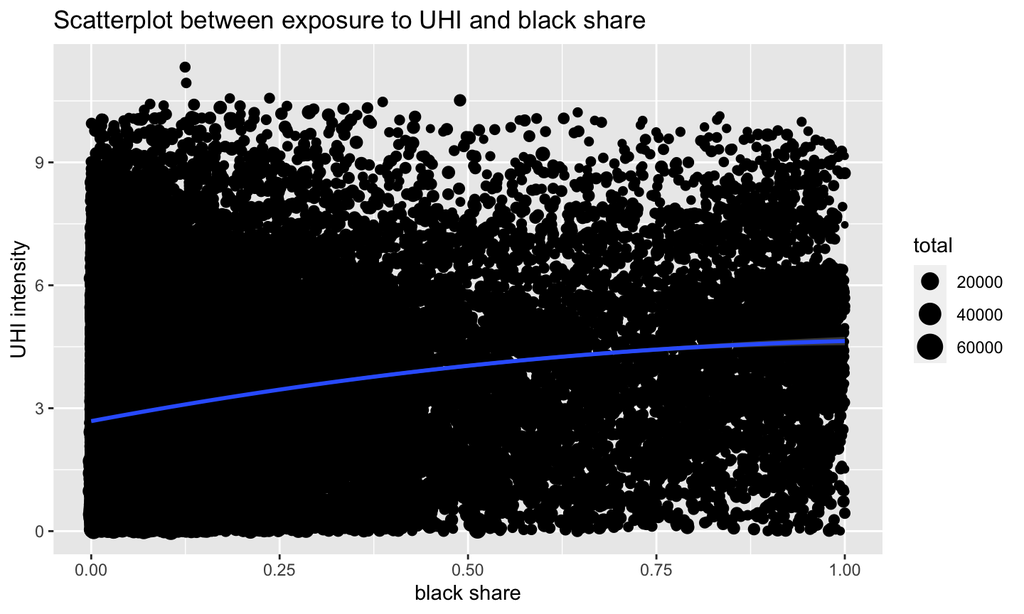

+ Moreover, there is an increase in the exposure of UHI with the increase in poverty rate in dominantly black population area

```r
t1_uhi_wtd_df
```

```
##                  Majority non-Black Majority Black       diff
## Not high poverty          2.5242798      3.8919328  1.3676530
## high poverty              3.2812892      4.1776046  0.8963154
## diff                      0.7570094      0.2856718 -0.4713376
```

```
##
## Call:
## lm(formula = UHI_summer_day ~ povt_rate, data = ct_black, weights = total)
##
## Weighted Residuals:
##     Min      1Q  Median      3Q     Max
## -481.91  -83.49    6.45   84.24  519.23
##
## Coefficients:
##             Estimate Std. Error t value Pr(>|t|)
## (Intercept) 3.662827   0.068092  53.792  < 2e-16 ***
## povt_rate   0.016955   0.002213   7.662 2.18e-14 ***
## ---
## Signif. codes:  0 '***' 0.001 '**' 0.01 '*' 0.05 '.' 0.1 ' ' 1
##
## Residual standard error: 131.2 on 5106 degrees of freedom
## Multiple R-squared:  0.01137,    Adjusted R-squared:  0.01117
## F-statistic: 58.71 on 1 and 5106 DF,  p-value: 2.176e-14
```